# Guided Project - Predicting Condominium Sale Prices

### 2) Outliers and Data Integrity Issues

```r
#Creating a copy before the transformation of NYC_condos
NYC_condos_original <- NYC_condos

#Removing the sale record of 200 000 000$ because its an extrem value
NYC_condos <- NYC_condos %>%
  filter(address != "165 East 66th St, Resi")

#Removing the sale record of this address because it's an exception and
#it will influence our model
NYC_condos <- NYC_condos %>%
  filter(address != "220 Central Park South, 50")
```

```r
#Investigation of the forty sale records in the Brooklyn borough
#This record sales represent the same transaction, the sale price represent the price for all
#the forty units, not the price for each unit.

#This is sale records where there are multiple entries
#It contains the transaction of 40 units
multi_unit_sales <- NYC_condos %>%
  group_by(sale_price, sale_date) %>%
  filter(n() >= 3) %>%
  arrange(desc(sale_price))

#Removing these multiple unit sales
NYC_condos <- NYC_condos %>%
  anti_join(multi_unit_sales)
```

#### Data Vizualisation without multi-unit sales

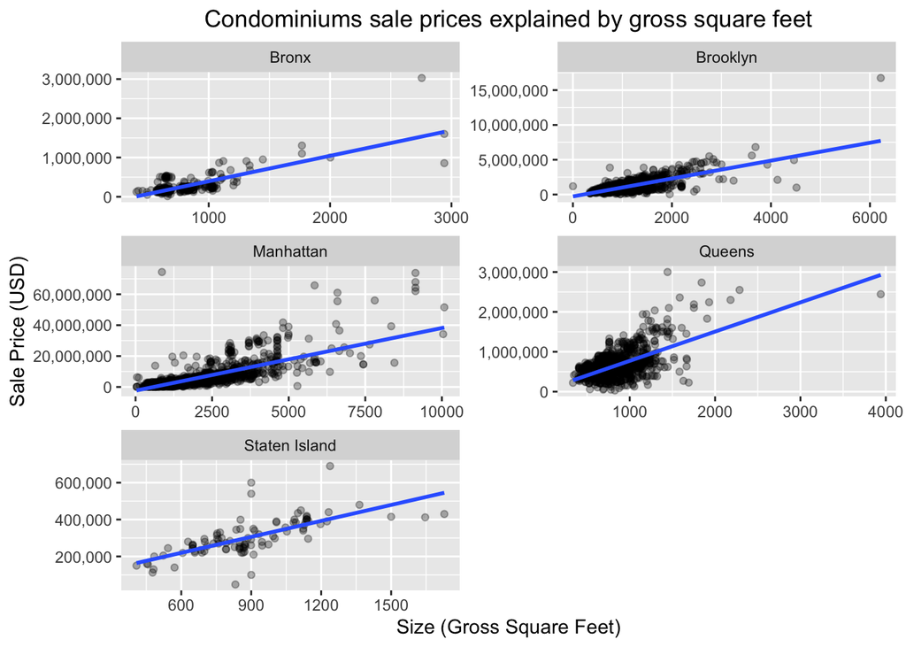

```r
ggplot(data = NYC_condos, aes(x = gross_square_feet,
                              y = sale_price)) +
  geom_point(alpha = 0.3) +
  scale_y_continuous(labels = scales::comma) +
  geom_smooth(method = "lm", se = FALSE) +
  facet_wrap(~ borough, scales = "free", ncol = 2) +
  labs(title = "Condominiums sale prices explained by gross square feet",
       x = "Size (Gross Square Feet)",
       y = "Sale Price (USD)") +
  theme(plot.title = element_text(hjust = 0.5))
```

### 3) Linear Regression Models for each Borough - coefficient Estimates

```r
#Nesting NYC_condos by borough
NYC_nested <- NYC_condos %>%
  group_by(borough) %>%
  nest()
```

```r
#Inspection of the data structure
NYC_nested
```

```
## # A tibble: 5 x 2
## # Groups:   borough [5]
##   borough       data
##   <chr>         <list>
## 1 Bronx         <tibble [330 × 19]>
## 2 Brooklyn      <tibble [1,697 × 19]>
## 3 Manhattan     <tibble [4,818 × 19]>
## 4 Queens        <tibble [1,004 × 19]>
## 5 Staten Island <tibble [96 × 19]>
```

```r
NYC_nested$data[[1]]
```

```
## # A tibble: 330 x 19
##    neighborhood building_class_… tax_class_at_pr… block   lot building_class_…
##    <chr>        <chr>            <chr>            <dbl> <dbl> <chr>
##  1 Bronxdale    13 Condos - Ele… 2                 4340  1025 R4
##  2 Bronxdale    13 Condos - Ele… 2                 4340  1039 R4
##  3 Bronxdale    13 Condos - Ele… 2                 4340  1078 R4
##  4 Bronxdale    13 Condos - Ele… 2                 4340  1107 R4
##  5 Bronxdale    13 Condos - Ele… 2                 4340  1168 R4
##  6 Bronxdale    13 Condos - Ele… 2                 4340  1225 R4
##  7 Bronxdale    13 Condos - Ele… 2                 4340  1245 R4
##  8 Bronxdale    13 Condos - Ele… 2                 4340  1246 R4
##  9 East Tremont 13 Condos - Ele… 2                 3125  1006 R4
## 10 Kingsbridge… 13 Condos - Ele… 2                 5764  1017 R4
## # … with 320 more rows, and 13 more variables: address <chr>,
## #   apartment_number <chr>, zip_code <dbl>, residential_units <dbl>,
## #   commercial_units <dbl>, total_units <dbl>, land_square_feet <dbl>,
## #   gross_square_feet <dbl>, year_built <dbl>, tax_class_at_time_of_sale <dbl>,
## #   building_class_at_time_of_sale <chr>, sale_price <dbl>, sale_date <dttm>
```

```r
# Fitting of linear models for each borough, individually
NYC_coefficients <- NYC_condos %>%
  group_by(borough) %>%
  nest() %>%
  mutate(linear_model = map(.x = data,
                            .f = ~lm(sale_price ~ gross_square_feet,
                                     data = .)))
```

```r
# Inspection of the result of code above
print(NYC_coefficients)
```

```
## # A tibble: 5 x 3
## # Groups:   borough [5]
##   borough       data                  linear_model
##   <chr>         <list>                <list>
## 1 Bronx         <tibble [330 × 19]>   <lm>
## 2 Brooklyn      <tibble [1,697 × 19]> <lm>
## 3 Manhattan     <tibble [4,818 × 19]> <lm>
## 4 Queens        <tibble [1,004 × 19]> <lm>
## 5 Staten Island <tibble [96 × 19]>    <lm>
```

```r
# More detailed summary
summary(NYC_coefficients$linear_model[[1]])
```

```
##
## Call:
## lm(formula = sale_price ~ gross_square_feet, data = .)
##
## Residuals:
##     Min      1Q  Median      3Q     Max
## -797569  -63973  -14647   30202 1493512
##
## Coefficients:
##                     Estimate Std. Error t value Pr(>|t|)
## (Intercept)       -254011.87   24667.81  -10.30   <2e-16 ***
## gross_square_feet     648.96      29.57   21.94   <2e-16 ***
## ---
## Signif. codes:  0 '***' 0.001 '**' 0.01 '*' 0.05 '.' 0.1 ' ' 1
##
## Residual standard error: 151500 on 328 degrees of freedom
## Multiple R-squared:  0.5948, Adjusted R-squared:  0.5936
## F-statistic: 481.5 on 1 and 328 DF,  p-value: < 2.2e-16
```

```r
# Generation of a tidy df of coefficient estimates that includes conf. int.
NYC_coefficients <- NYC_condos %>%
  group_by(borough) %>%
  nest() %>%
    mutate(linear_model = map(.x = data,
                            .f = ~lm(sale_price ~ gross_square_feet,
                                     data = .))) %>%
  mutate(tidy_coefficients = map(.x = linear_model,
                                 .f = tidy,
                                 conf.int = TRUE))
# Inspection of the new data structure
print(NYC_coefficients)
```

```
## # A tibble: 5 x 4
## # Groups:   borough [5]
##   borough       data                  linear_model tidy_coefficients
##   <chr>         <list>                <list>       <list>
## 1 Bronx         <tibble [330 × 19]>   <lm>         <tibble [2 × 7]>
## 2 Brooklyn      <tibble [1,697 × 19]> <lm>         <tibble [2 × 7]>
## 3 Manhattan     <tibble [4,818 × 19]> <lm>         <tibble [2 × 7]>
## 4 Queens        <tibble [1,004 × 19]> <lm>         <tibble [2 × 7]>
## 5 Staten Island <tibble [96 × 19]>    <lm>         <tibble [2 × 7]>
```

```r
# Extraction of the new column added (`tidy_coefficients`)
print(NYC_coefficients$tidy_coefficients[[1]])
```

```
## # A tibble: 2 x 7
##   term              estimate std.error statistic  p.value conf.low conf.high
##   <chr>                <dbl>     <dbl>     <dbl>    <dbl>    <dbl>     <dbl>
## 1 (Intercept)       -254012.   24668.      -10.3 9.89e-22 -302539.  -205485.
## 2 gross_square_feet     649.      29.6      21.9 2.58e-66     591.      707.
```

```r
# Unnesting to a tidy dataframe of coefficient estimates
NYC_coefficients_tidy <- NYC_coefficients %>%
  select(borough, tidy_coefficients) %>%
  unnest(cols = tidy_coefficients)
print(NYC_coefficients_tidy)
```

```
## # A tibble: 10 x 8
## # Groups:   borough [5]
##    borough   term      estimate std.error statistic   p.value conf.low conf.high
##    <chr>     <chr>        <dbl>     <dbl>     <dbl>     <dbl>    <dbl>     <dbl>
##  1 Bronx     (Interce…  -2.54e5   24668.     -10.3  9.89e- 22  -3.03e5  -205485.
##  2 Bronx     gross_sq…   6.49e2      29.6     21.9  2.58e- 66   5.91e2      707.
##  3 Brooklyn  (Interce…  -2.72e5   34487.      -7.88 5.64e- 15  -3.40e5  -204248.
##  4 Brooklyn  gross_sq…   1.29e3      29.7     43.2  1.06e-275   1.23e3     1344.
##  5 Manhattan (Interce…  -2.39e6   72893.     -32.8  1.53e-213  -2.54e6 -2250437.
##  6 Manhattan gross_sq…   4.05e3      44.9     90.3  0.          3.97e3     4142.
##  7 Queens    (Interce…   3.99e4   28311.       1.41 1.59e-  1  -1.56e4    95481.
##  8 Queens    gross_sq…   7.33e2      32.0     22.9  8.14e- 94   6.70e2      795.
##  9 Staten I… (Interce…   4.64e4   28256.       1.64 1.04e-  1  -9.67e3   102536.
## 10 Staten I… gross_sq…   2.89e2      30.7      9.41 3.30e- 15   2.28e2      349.
```

```r
# slope estimate fitering
NYC_slope <- NYC_coefficients_tidy %>%
  filter(term == "gross_square_feet") %>%
  arrange(estimate)
print(NYC_slope)
```

```
## # A tibble: 5 x 8
## # Groups:   borough [5]
##   borough    term      estimate std.error statistic   p.value conf.low conf.high
##   <chr>      <chr>        <dbl>     <dbl>     <dbl>     <dbl>    <dbl>     <dbl>
## 1 Staten Is… gross_sq…     289.      30.7      9.41 3.30e- 15     228.      349.
## 2 Bronx      gross_sq…     649.      29.6     21.9  2.58e- 66     591.      707.
## 3 Queens     gross_sq…     733.      32.0     22.9  8.14e- 94     670.      795.
## 4 Brooklyn   gross_sq…    1285.      29.7     43.2  1.06e-275    1227.     1344.
## 5 Manhattan  gross_sq…    4054.      44.9     90.3  0.           3966.     4142.
```

From the output above, we can see that the slopes are very different. In Staten Island, an increase of one square foot is estimated to increase the sale price by about 288$. In contrast, in Manhattan, an increase of one square foot is estimated to increase the sale price by about 4054$.

Using the results from the previous chunk of code, we can infer that, in general, a condominium in Staten Island will cost less per square foot than in Manhattan.